# A Bayesian Approach Modeling the Industrial Production Index

## Overview

This notebook contains the R code for the Bayesian analysis of the Industrial Production Index (IPI). The detailed explanation of the results are exposed in the report. The modelling is performed using the `BAS` library.

### Package and Data import Package import:

```r
library("ggplot2")
library("BAS")
library("loo")
library(tidyr)
library(dplyr)
```

Read data:

```r
data_complete = read.csv("indprod.csv")
data_complete$DATE = as.Date(data_complete$DATE)
```

## Data Pre-Processing

First visualization of the dataset:

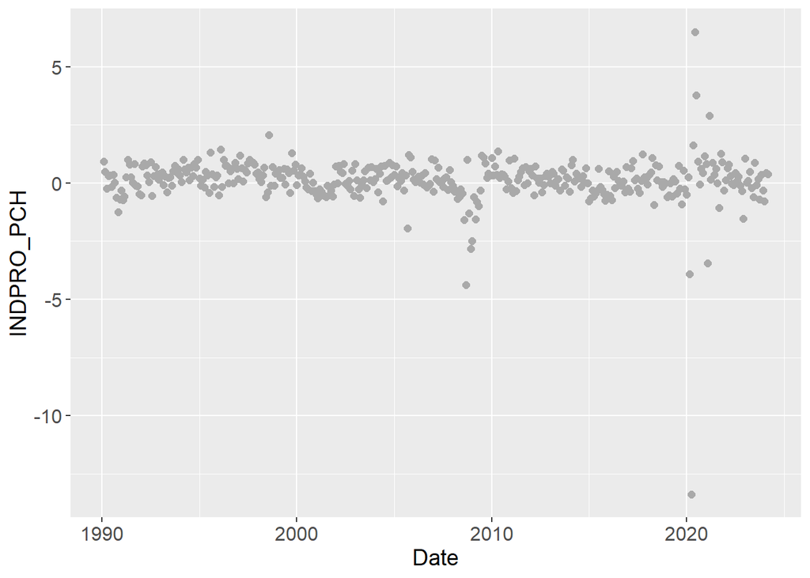

```r
g1 = ggplot(data_complete, aes(x = DATE, y = INDPRO_PCH)) +
  geom_point(color = "darkgrey", size = 2) +  # Punti neri
  labs(x = "Date", y = "INDPRO_PCH") +
  theme(
    plot.title = element_text(hjust = 0.5, size = 16, face = "bold"),
    axis.title.x = element_text(size = 14),
    axis.title.y = element_text(size = 14),
    axis.text = element_text(size = 12)
  )
g1
```

The dataset contains a lot of outliers that can increase the model’s error. For this reason we can filter the data where the modulus is to far with respect to the others.

See: [Bayesian Robustness to Outliers in Linear Regression and Ratio Estimation](https://arxiv.org/pdf/1612.05307).

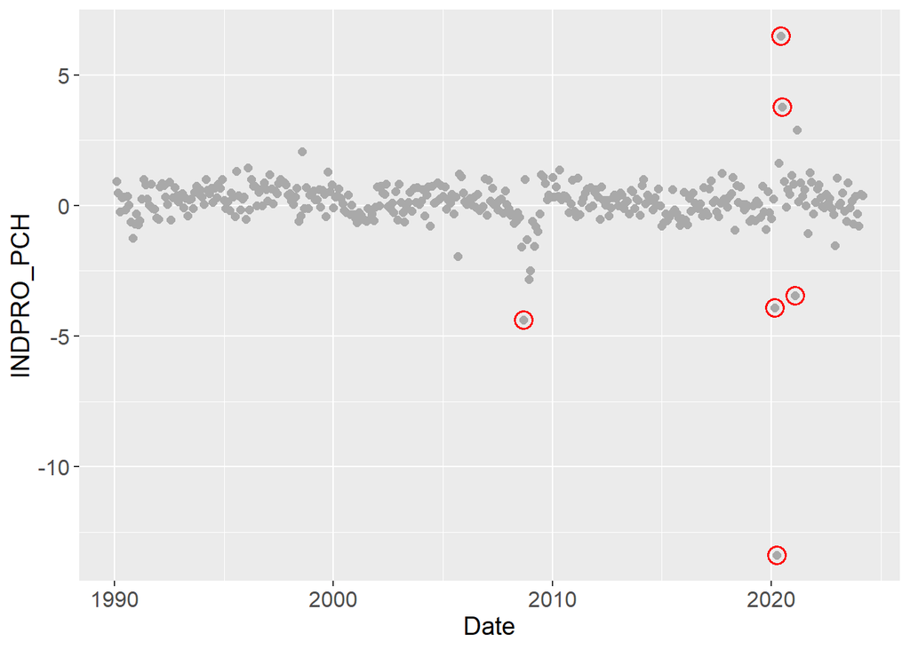

```r
data_limit = 3
g2 = g1 +
  geom_point(data = subset(data_complete, INDPRO_PCH > data_limit | INDPRO_PCH < -data_limit),
             aes(x = DATE, y = INDPRO_PCH),
             color = "red",
             size = 4.0, shape = 21, stroke = 1.0)

g2
```

Deleting outliers from dataset:

```r
limit_min = -3
limit_max = 3
data = subset(data_complete, INDPRO_PCH >= limit_min & INDPRO_PCH <= limit_max)
```

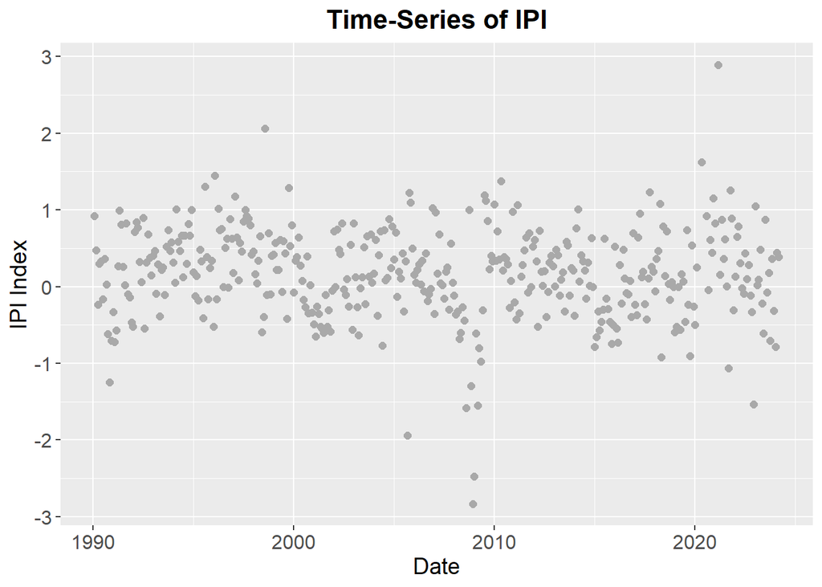

```r
g3 = ggplot(data, aes(x = DATE, y = INDPRO_PCH)) +
    geom_point(color = "darkgrey", size = 2) +
    labs(title = "Time-Series of IPI", x = "Date", y = "IPI Index") +
    theme(
      plot.title = element_text(hjust = 0.5, size = 16, face = "bold"),
      axis.title.x = element_text(size = 14),
      axis.title.y = element_text(size = 14),
      axis.text = element_text(size = 12)
    )
g3
```

```r
# Define covarietes
data_ = data[, -1]
```

We split randomly the dataset in two parts: - `train_data`: contains the data used for fitting the model - `test_data` : contains the data used for test the model

```r
set.seed(123)
train_index = sample(1:nrow(data_), 0.7 * nrow(data_))

# Training set
train_data  = data[train_index, ]
train_data_ = data_[train_index, ]

# Testing set
test_data  = data[-train_index, ]
test_data_ = data_[-train_index, ]
```

# Bayesian Linear Regression

We try to fit the model with different priors: - Zellner’s G-prior - Zellner’s JZS For a better readability of the code we define a function based on `bas.lm`.

```r
bas_lm = function (data= train_data_, prior="g-prior", alpha=1.0){
  local_model = bas.lm(INDPRO_PCH ~ ., data =  data,
                       prior=prior, alpha=alpha,
                       modelprior = Bernoulli(1),
                       include.always = ~ .,
                       n.models = 1)
  return(local_model)
}
```

A useful function for plotting credible intervals:

```r
plot_credible_interval = function(intervals, alpha){
  # Conversion to dataframe for better plotting
  df = as.data.frame(intervals)[1:12, ]
  ggplot(df, aes(x = rownames(df), y = df[, 3], ymin = df[,1], ymax = df[,2])) +
    geom_point(size = 2) +
    geom_errorbar(width = 0.2) +
    labs(y ="Estimate", x = NULL) +
    theme(axis.text.x = element_text(angle = 90, vjust = 0.5, hjust = 1))
}
```

```r
compare_different_alpha = function(data_train, data_test, prior, alphas){

  results = data.frame(DATE=data_test$DATE)
  for (alpha in alphas) {

    m = bas_lm(data=data_train, prior=prior, alpha=alpha)

    pred = predict(m, newdata=data_test)

    results[[paste("alpha=", alpha, sep = "")]] = pred$fit
  }
  return(results)
}
```

## Zellner’s G-prior

```r
alphapar = 10.0
model_g_prior = bas_lm(data=train_data_, "g-prior", alphapar)
beta_g_prior = coef(model_g_prior)
beta_g_prior
```

```
##
##  Marginal Posterior Summaries of Coefficients:
##
##  Using  BMA
##
##  Based on the top  1 models
##                           post mean   post SD     post p(B != 0)
## Intercept                  0.1416370   0.0319752   1.0000000
## WILL5000PR_PCH             0.0120021   0.0124154   1.0000000
## HSN1F_PCH                 -0.0015625   0.0045395   1.0000000
## DCOILBRENTEU_PCH           0.0041569   0.0044509   1.0000000
## CORESTICKM159SFRBATL_PCH  -0.0128598   0.0061016   1.0000000
## TOTALSA_PCH                0.0176788   0.0055019   1.0000000
## CPIUFDSL_PCH              -0.1232113   0.1437500   1.0000000
## DEXJPUS_PCH                0.0072143   0.0123045   1.0000000
## MICH_PCH                   0.0004363   0.0013139   1.0000000
## VIXCLS_PCH                 0.0098944   0.0027795   1.0000000
## PAYEMS_PCH                 1.1195162   0.1880141   1.0000000
## PPIACO_PCH                 0.0624519   0.0385000   1.0000000
```

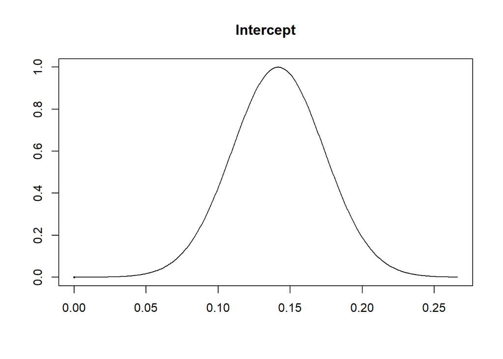

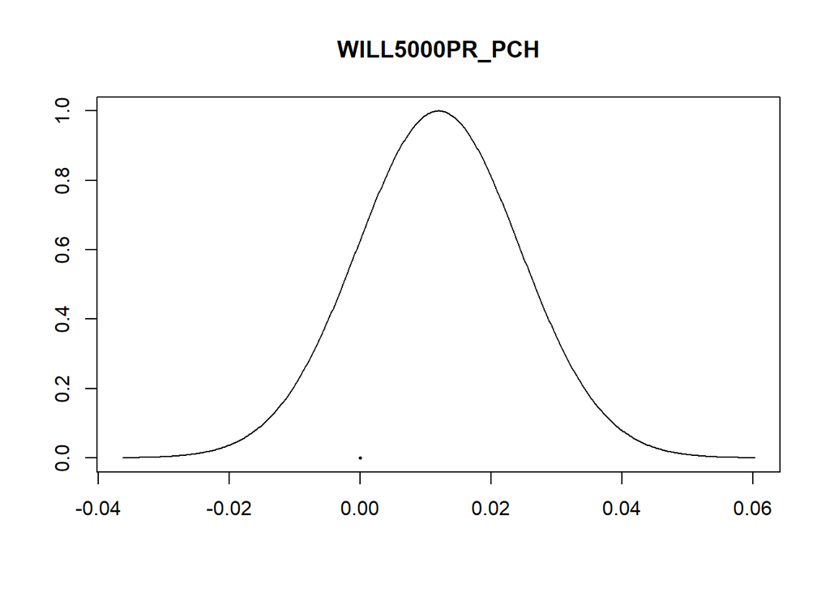

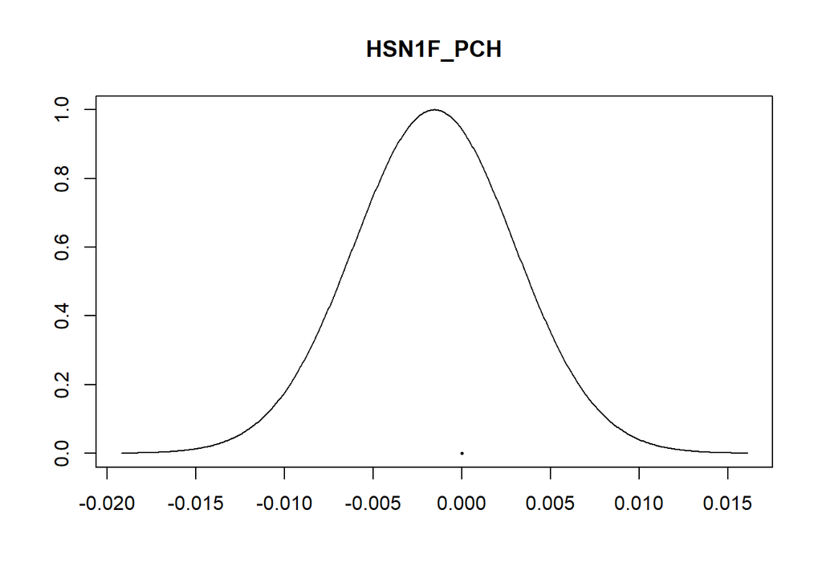

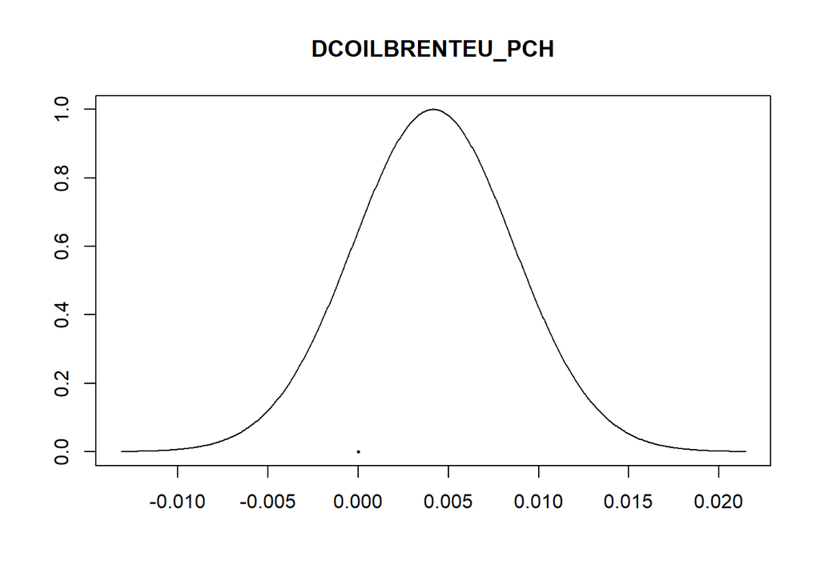

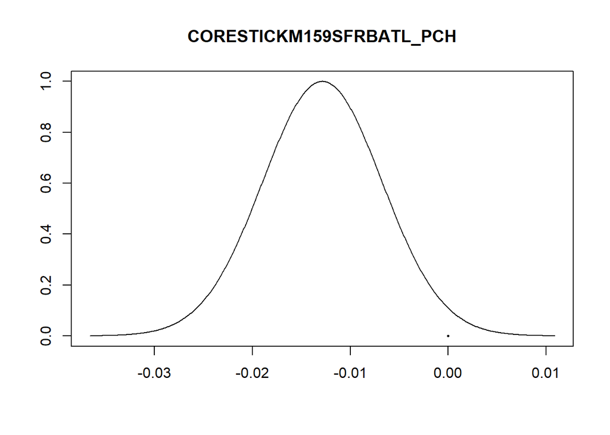

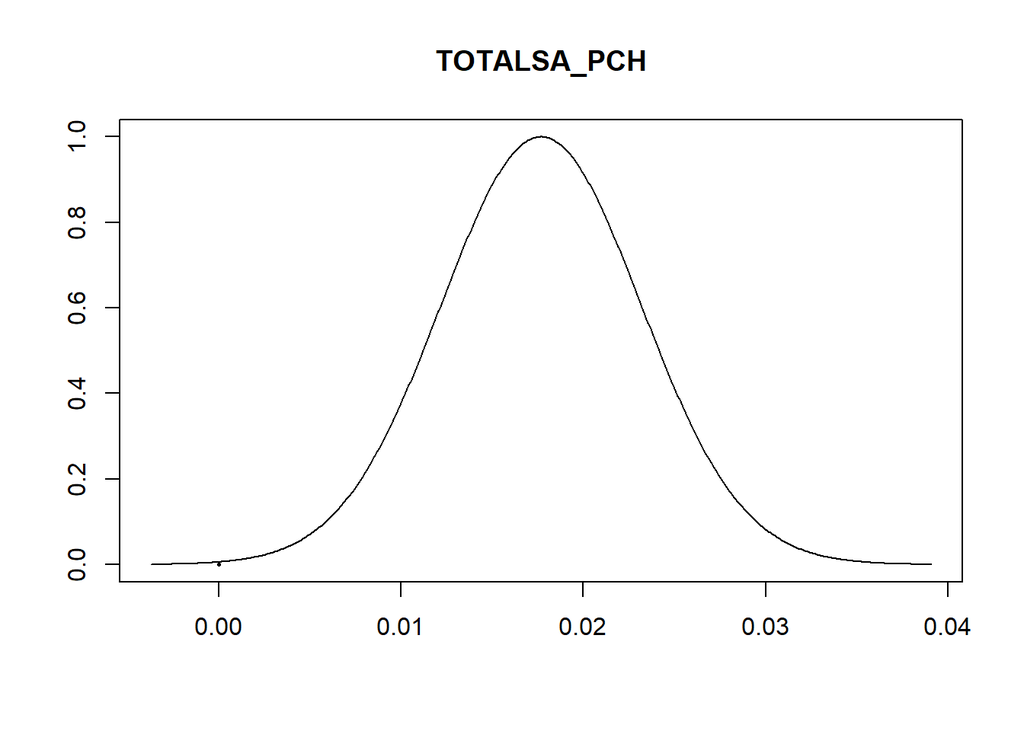

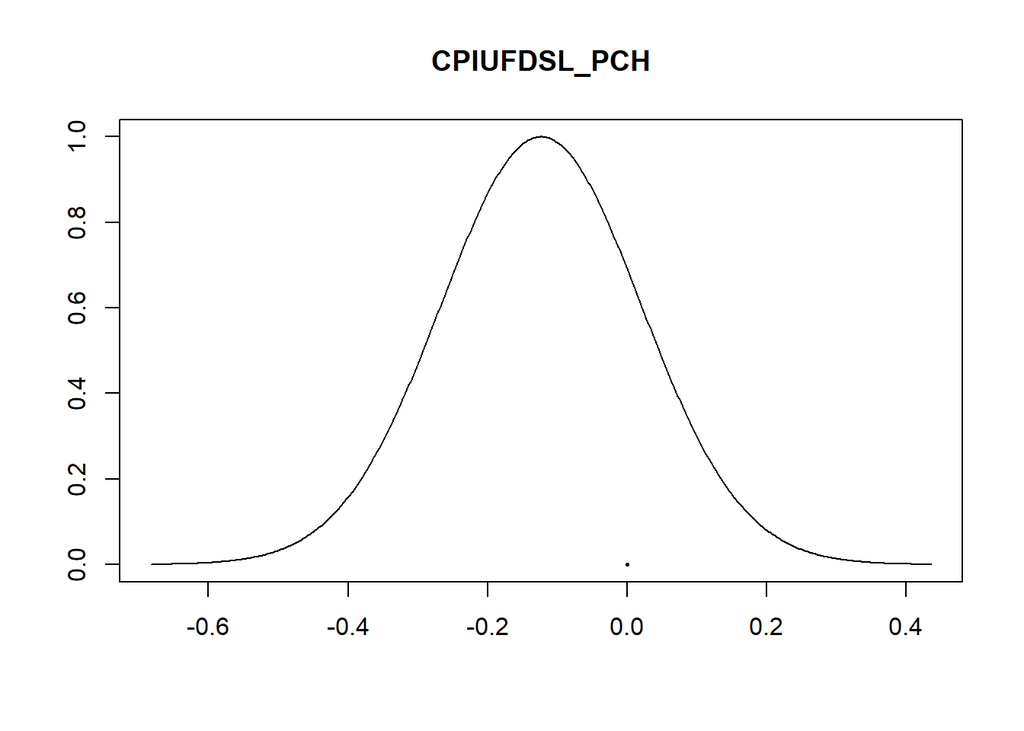

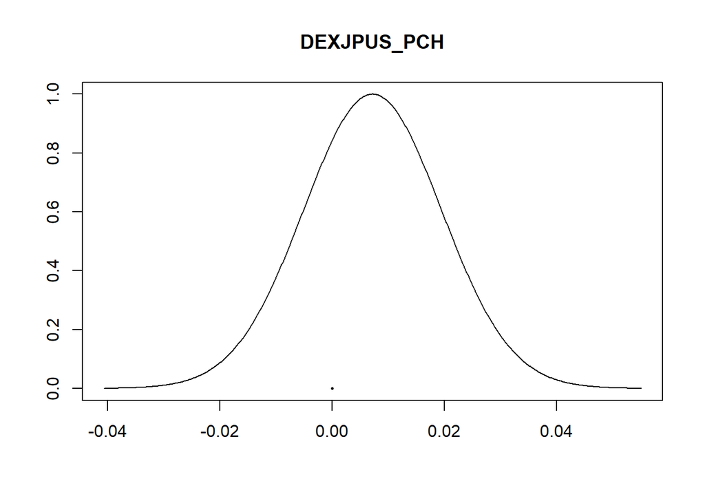

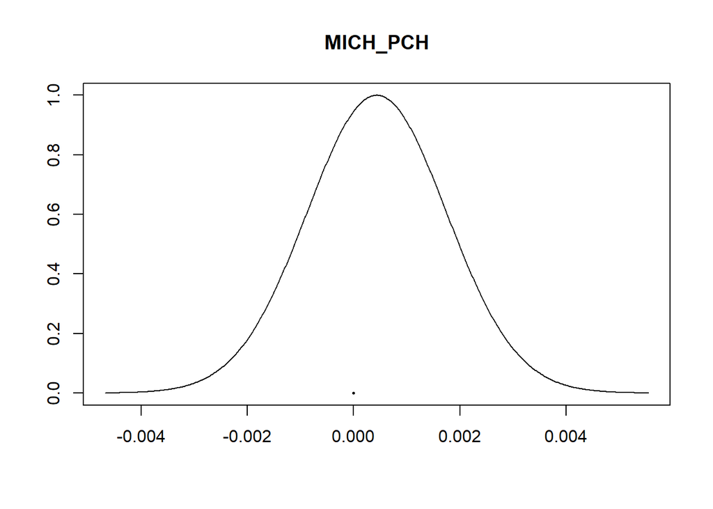

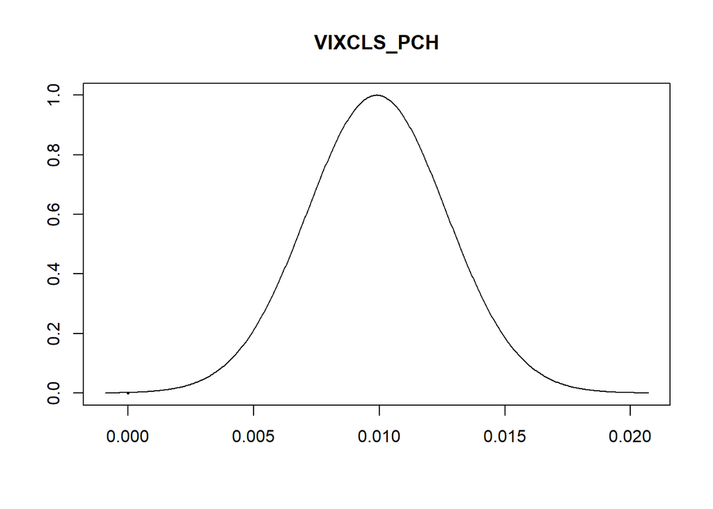

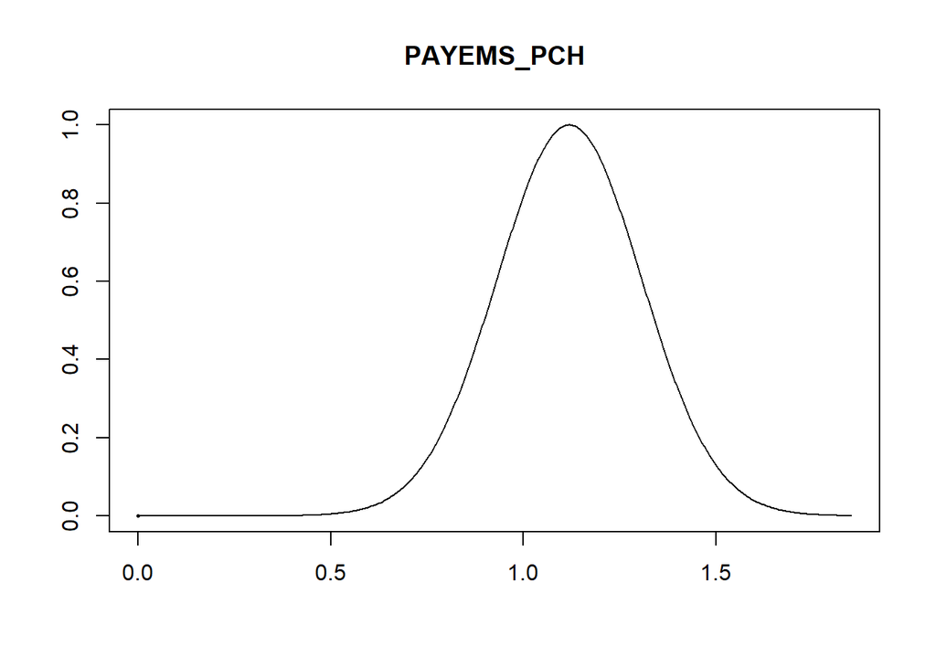

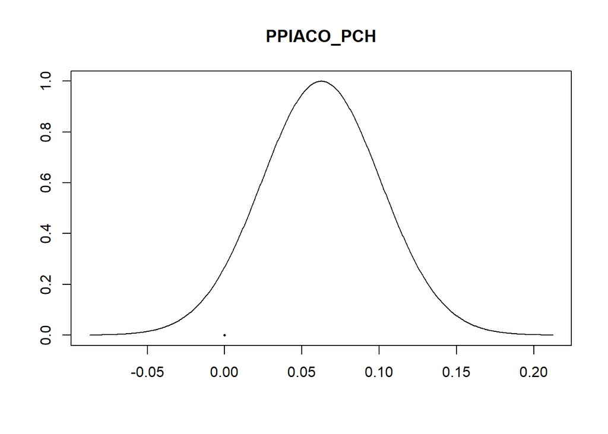

```r
plot(beta_g_prior, subset = 1:12, ask=F)
```

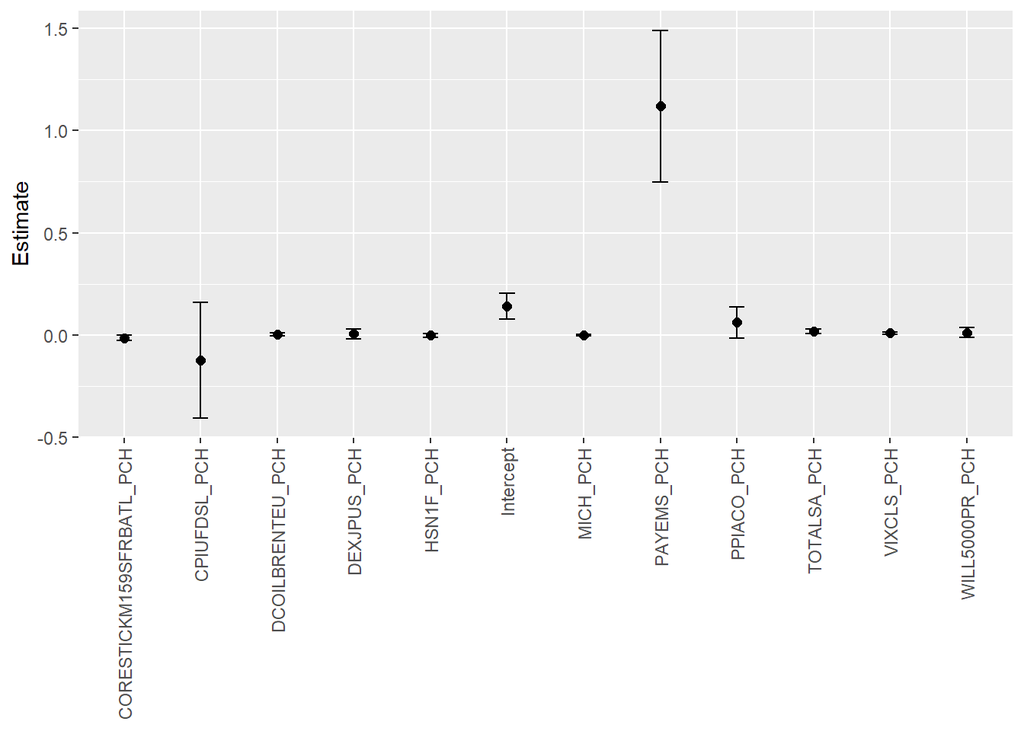

```r
ci_g_prior = confint(beta_g_prior)
plot_credible_interval(ci_g_prior, alphapar)
```

Manual definition of the model using different value of the parameters: in particular we use the posterior mean, the upper and lower bounds of the credible interval.

```r
data_1 = data_[, -1]
beta_mean = beta_g_prior$postmean

# Model
y_hat =  beta_mean[1] +
         beta_mean[2] *   train_data_$WILL5000PR_PCH +
         beta_mean[3] *   train_data_$HSN1F_PCH +
         beta_mean[4] *   train_data_$DCOILBRENTEU_PCH +
         beta_mean[5] *   train_data_$CORESTICKM159SFRBATL_PCH +
         beta_mean[6] *   train_data_$TOTALSA_PCH +
         beta_mean[7] *   train_data_$CPIUFDSL_PCH +
         beta_mean[8] *   train_data_$DEXJPUS_PCH +
         beta_mean[9] *   train_data_$MICH_PCH +
         beta_mean[10] *  train_data_$VIXCLS_PCH +
         beta_mean[11] *  train_data_$PAYEMS_PCH +
         beta_mean[12] *  train_data_$PPIACO_PCH
```

```r
out = confint(beta_g_prior)[, 1:2]
beta_low = out[,1]
beta_up = out[,2]

y_low =  beta_low[1] +
         beta_low[2] *   train_data_$WILL5000PR_PCH +
         beta_low[3] *   train_data_$HSN1F_PCH +
         beta_low[4] *   train_data_$DCOILBRENTEU_PCH +
         beta_low[5] *   train_data_$CORESTICKM159SFRBATL_PCH +
         beta_low[6] *   train_data_$TOTALSA_PCH +
         beta_low[7] *   train_data_$CPIUFDSL_PCH +
         beta_low[8] *   train_data_$DEXJPUS_PCH +
         beta_low[9] *   train_data_$MICH_PCH +
         beta_low[10] *  train_data_$VIXCLS_PCH +
         beta_low[11] *  train_data_$PAYEMS_PCH +
         beta_low[12] *  train_data_$PPIACO_PCH

y_up =   beta_up[1] +
         beta_up[2] *   train_data_$WILL5000PR_PCH +
         beta_up[3] *   train_data_$HSN1F_PCH +
         beta_up[4] *   train_data_$DCOILBRENTEU_PCH +
         beta_up[5] *   train_data_$CORESTICKM159SFRBATL_PCH +
         beta_up[6] *   train_data_$TOTALSA_PCH +
         beta_up[7] *   train_data_$CPIUFDSL_PCH +
         beta_up[8] *   train_data_$DEXJPUS_PCH +
         beta_up[9] *   train_data_$MICH_PCH +
         beta_up[10] *  train_data_$VIXCLS_PCH +
         beta_up[11] *  train_data_$PAYEMS_PCH +
         beta_up[12] *  train_data_$PPIACO_PCH
```

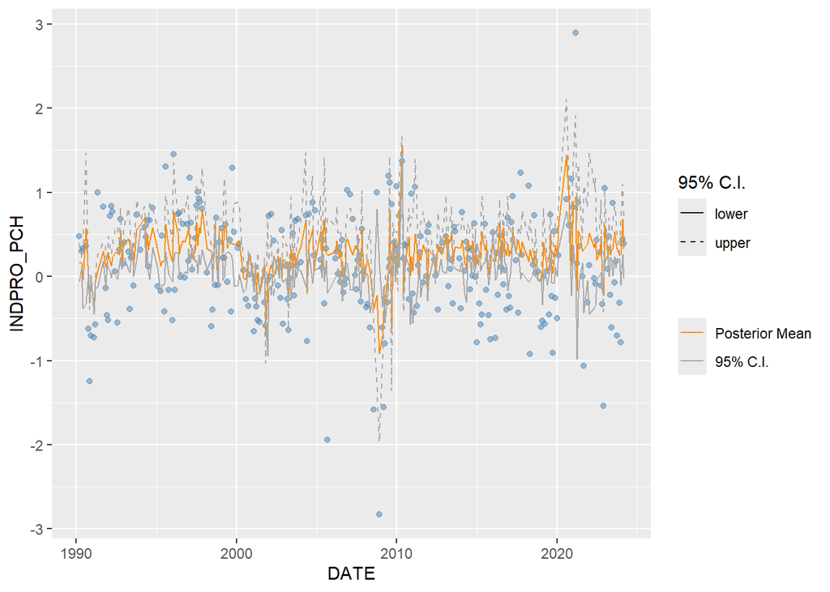

```r
# Plot
plot1 =
  ggplot(data = train_data, aes(x = DATE, y = INDPRO_PCH)) +
  geom_point(color = "steelblue", alpha=0.5) + xlab("DATE") +
  geom_line(data = train_data,
            aes(x = DATE, y = y_hat, color = "first"),  lty = 1) +
  geom_line(data = train_data,
            aes(x = DATE, y = y_low, color = "second", lty = "second")) +
  geom_line(data = train_data,
            aes(x = DATE, y = y_up,  color= "second", lty = "third")) +
  scale_colour_manual(values=c("first"="darkorange", "second"="darkgrey"), labels=c("Posterior Mean","95% C.I."), name="") +
  scale_linetype_manual(values = c(1, 2), labels = c("lower" , "upper"),
                        name = "95% C.I.")

plot1
```

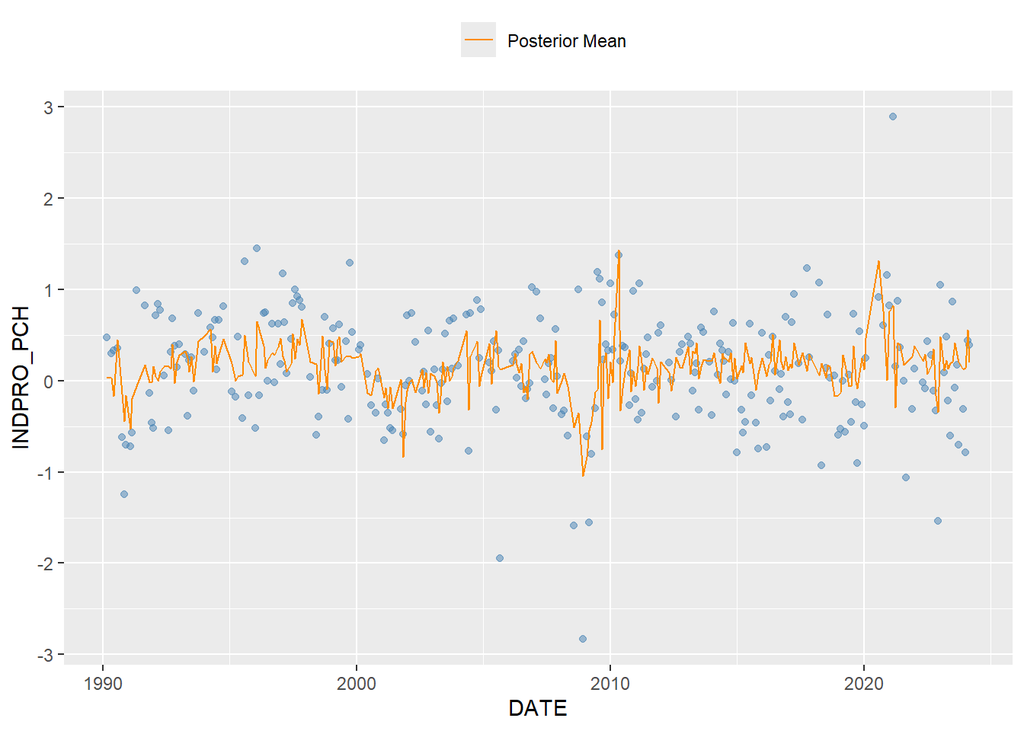

```r
y_fit = predict(model_g_prior, newdata = train_data_)$fit
plot2 =
  ggplot(data = train_data, aes(x = DATE, y = INDPRO_PCH)) +
  geom_point(color = "steelblue", alpha=0.5) + xlab("DATE") +
  geom_line(data = train_data,
            aes(x = DATE, y = y_fit, color = "first"),  lty = 1) +
  scale_colour_manual(values="darkorange", labels="Posterior Mean", name="") +
  scale_linetype_manual(values = c(1, 2), labels = c("lower" , "upper"),
                        name = "95% C.I.") +
  theme(legend.position = "top")

plot2
```

Predicitons using the test dataset and the posterior mean of vector beta

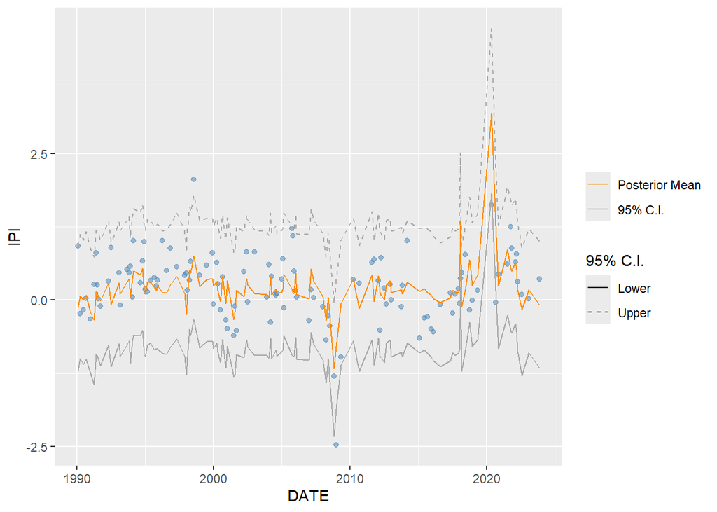

```r
predictions = predict(model_g_prior,
                      newdata = test_data_,
                      se.fit = TRUE)
pred_intervals = confint(predictions, level = 0.95)
y_pred_low = pred_intervals[,1]
y_pred_up = pred_intervals[,2]

ggplot(data = test_data, aes(x = DATE, y = INDPRO_PCH)) +
  geom_point(color = "steelblue", alpha=0.5) + xlab("DATE") +
  geom_line(data = test_data,
            aes(x = DATE, y = predictions$fit, color = "first"), lty = 1) +
  geom_line(data = test_data,
            aes(x = DATE, y = y_pred_low, color = "second", lty = "second")) +
  geom_line(data = test_data,
            aes(x = DATE, y = y_pred_up, color = "second", lty = "third")) +

  scale_colour_manual(values = c("first" = "darkorange", "second" = "darkgrey"),
                      labels = c("Posterior Mean", "95% C.I."),
                      name = "") +
  scale_linetype_manual(values = c(1, 2, 2),
                        labels = c("Lower", "Upper"),
                        name = "95% C.I.") +
  labs(x="DATE", y="IPI")
```

### Model Selection using Bayesian Information Criterion (BIC)

```r
cog.BIC = bas.lm(INDPRO_PCH ~ ., data = train_data_,
                 prior = "BIC", modelprior = uniform())

round(summary(cog.BIC), 2)
```

```
##                          P(B != 0 | Y) model 1 model 2 model 3 model 4 model 5
## Intercept                         1.00    1.00    1.00    1.00    1.00    1.00
## WILL5000PR_PCH                    0.12    0.00    0.00    0.00    0.00    0.00
## HSN1F_PCH                         0.06    0.00    0.00    0.00    0.00    0.00
## DCOILBRENTEU_PCH                  0.30    0.00    0.00    1.00    1.00    0.00
## CORESTICKM159SFRBATL_PCH          0.58    1.00    0.00    1.00    0.00    0.00
## TOTALSA_PCH                       0.96    1.00    1.00    1.00    1.00    1.00
## CPIUFDSL_PCH                      0.12    0.00    0.00    0.00    0.00    0.00
## DEXJPUS_PCH                       0.07    0.00    0.00    0.00    0.00    0.00
## MICH_PCH                          0.07    0.00    0.00    0.00    0.00    0.00
## VIXCLS_PCH                        0.99    1.00    1.00    1.00    1.00    1.00
## PAYEMS_PCH                        1.00    1.00    1.00    1.00    1.00    1.00
## PPIACO_PCH                        0.64    1.00    1.00    0.00    0.00    0.00
## BF                                  NA    1.00    0.47    0.28    0.28    0.16
## PostProbs                           NA    0.25    0.12    0.07    0.07    0.04
## R2                                  NA    0.24    0.22    0.24    0.22    0.20
## dim                                 NA    6.00    5.00    6.00    5.00    4.00
## logmarg                             NA -632.84 -633.59 -634.12 -634.12 -634.70
```

```r
# Find the index of the model with largest `logmarg`:
cog.best = which.max(cog.BIC$logmarg)

# Print the selected subset of variables:
selectedVars = cog.BIC$which[[cog.best]]+1
cog.BIC$namesx[selectedVars]
```

```
## [1] "Intercept"                "CORESTICKM159SFRBATL_PCH"
## [3] "TOTALSA_PCH"              "VIXCLS_PCH"
## [5] "PAYEMS_PCH"               "PPIACO_PCH"
```

Now we will proceed with the same steps using only the variables selected with BIC.

```r
vars = cog.BIC$namesx[selectedVars]
vars = c("DATE", "INDPRO_PCH", vars)
vars = intersect(vars, names(train_data))  # Filtra solo le colonne esistenti

ms_data_train = train_data[, vars]
ms_data_train_ = ms_data_train[-1]

ms_data_test = test_data[, vars]
ms_data_test_ = ms_data_test[-1]
```

We build and train the model using the g-prior.

```r
alphapar = 10
model_g_prior_ms = bas_lm(data=ms_data_train_, prior="g-prior", alpha=alphapar)
```

```r
beta_ms = coef(model_g_prior_ms)
beta_ms
```

```
##
##  Marginal Posterior Summaries of Coefficients:
##
##  Using  BMA
##
##  Based on the top  1 models
##                           post mean  post SD    post p(B != 0)
## Intercept                  0.141637   0.031839   1.000000
## CORESTICKM159SFRBATL_PCH  -0.014897   0.005871   1.000000
## TOTALSA_PCH                0.018102   0.005361   1.000000
## VIXCLS_PCH                 0.007711   0.001970   1.000000
## PAYEMS_PCH                 1.108472   0.181835   1.000000
## PPIACO_PCH                 0.087123   0.029259   1.000000
```

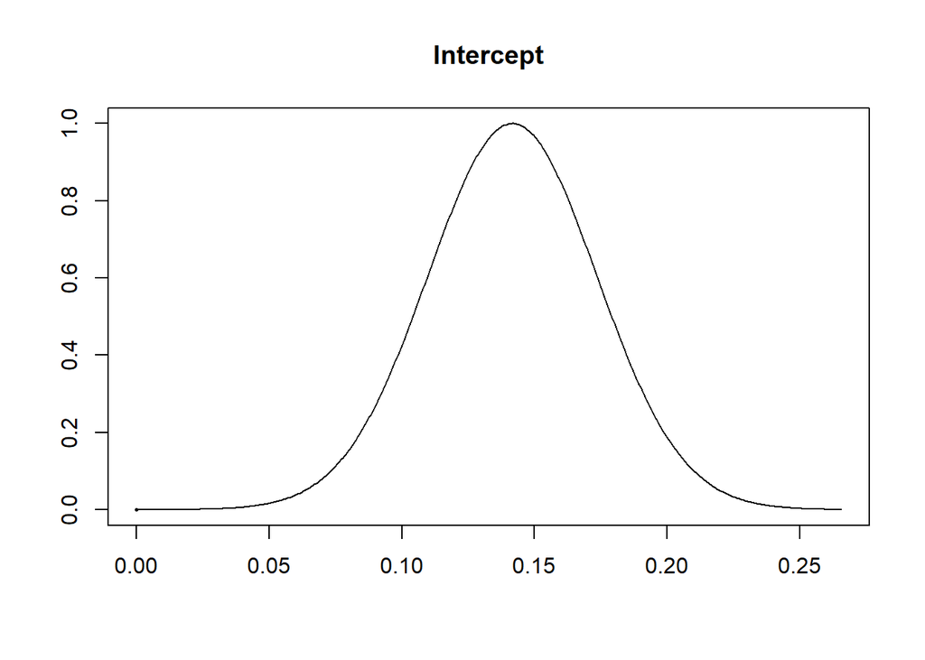

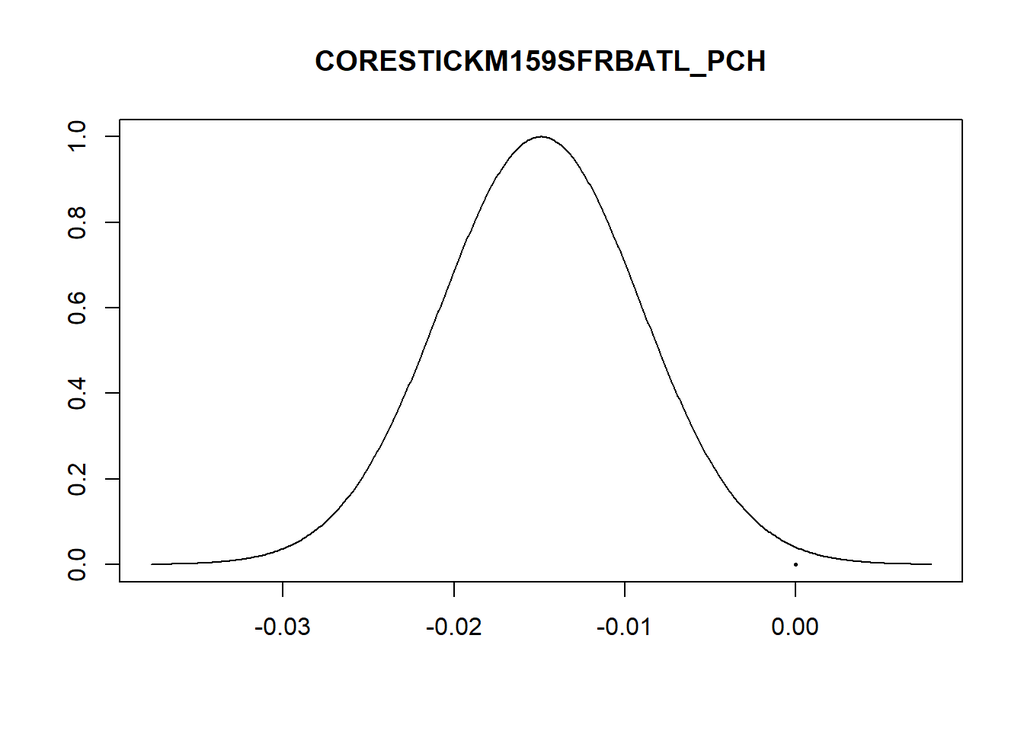

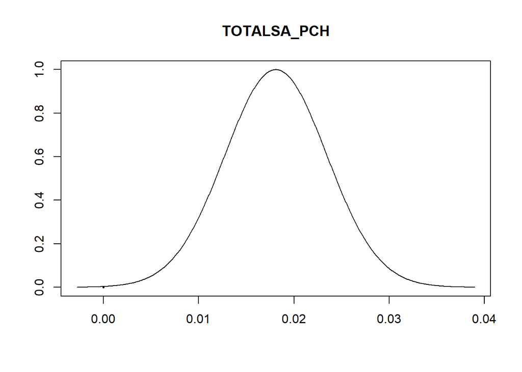

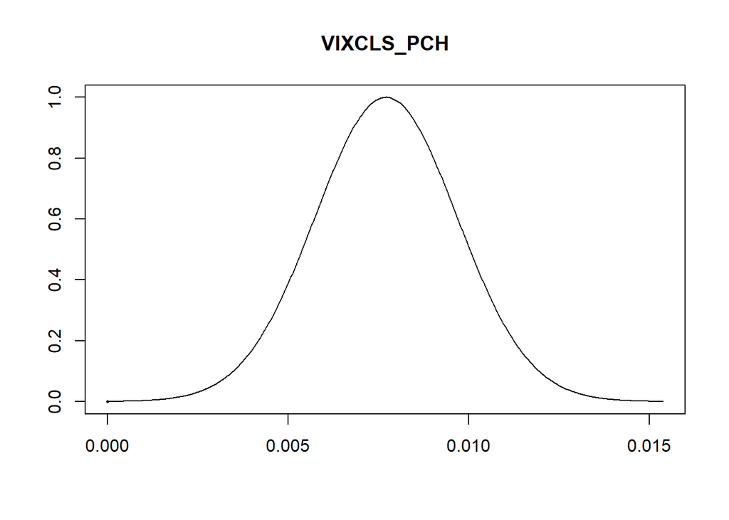

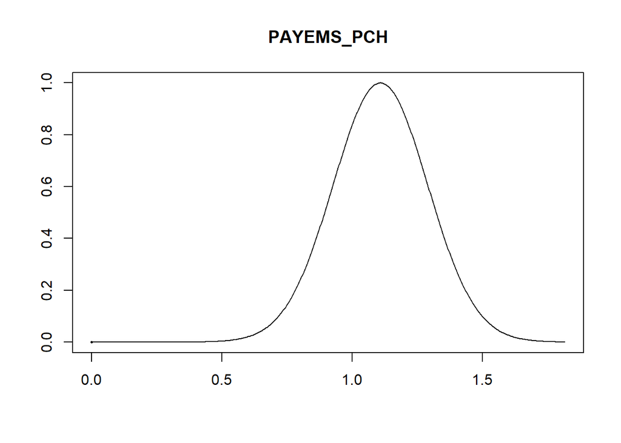

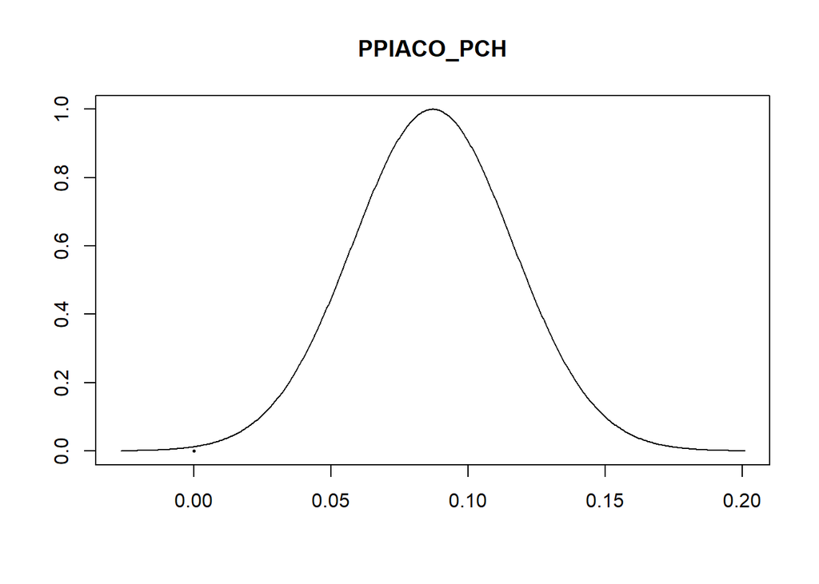

```r
plot(beta_ms, ask=F)
```

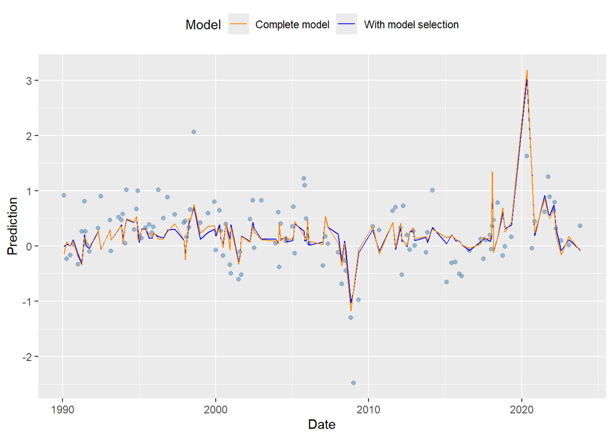

```r
predictions_ms = predict(model_g_prior_ms, newdata = ms_data_test_, se.fit = TRUE)

ggplot(data = test_data, aes(x = DATE, y = INDPRO_PCH)) +
        geom_point(color = "steelblue", alpha=0.5) + xlab("DATE") +
        geom_line(data = ms_data_test,
                  aes(x = DATE,
                      y = predictions_ms$fit,
                      color = "With model selection"),
                  lty = 1) +
        geom_line(data = test_data,
                  aes(x = DATE,
                      y = predictions$fit,
                      color="Complete model"), lty=1) +
        labs(
          x="Date",
          y="Prediction"
        ) +
        theme(legend.position = "top")+
        scale_color_manual(name = "Model", values = c("With model selection" = "blue", "Complete model" = "darkorange"))
```

Now, the idea is analyze the behaviour of the model when alpha changes.

```r
alphas = c(0.001, 0.1, 1, 10, 100, dim(ms_data_train_)[1])
results = compare_different_alpha(ms_data_train_, ms_data_test, "g-prior", alphas)
```

We plot the different predictions in a single image:

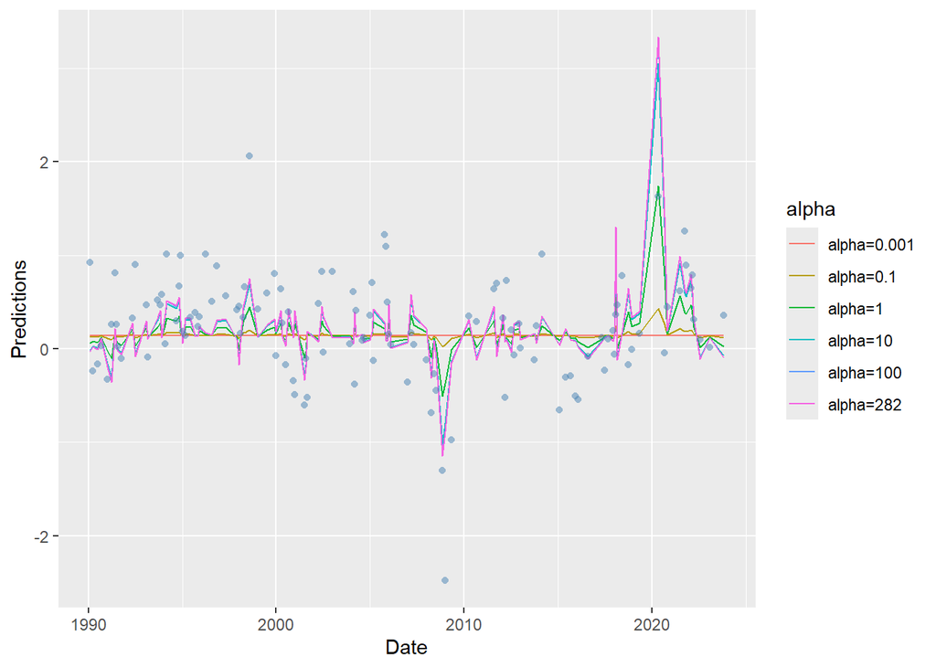

```r
# Change the dataframe into long
results_long_g = results %>%
  pivot_longer(cols = -DATE,
               names_to = "alpha",
               values_to = "predictions")

ggplot(results_long_g, aes(x = DATE, y = predictions, color = alpha)) +
  geom_line() +
  geom_point(data = ms_data_test,
             aes(x = DATE, y = INDPRO_PCH),
             color = "steelblue",
             shape = 16,
             alpha=0.5) +
  labs(x = "Date",
       y = "Predictions")
```

Here we compute the Mean Square Error (MSE) for each model in order to compere different models.

```r
mse = function(actual, predicted) {
  mean((actual - predicted)^2)
}

mse_values = numeric(length(alphas))

# Compute MSE for each value of alpha
for (i in 1:length(alphas)) {
  alpha_column = paste("alpha", alphas[i], sep = "=")
  mse_values[i] = mse(ms_data_test$INDPRO_PCH, results[[alpha_column]])
}
mse_df = data.frame(alpha = alphas, MSE = mse_values)
mse_df
```

```
##     alpha       MSE
## 1   0.001 0.3259736
## 2   0.100 0.3045504
## 3   1.000 0.2449915
## 4  10.000 0.2476026
## 5 100.000 0.2554939
## 6 282.000 0.2562176
```

## Zellner’s JZS

```r
alphapar = 1
model_jzs_prior = bas_lm(data=train_data, prior="JZS", alpha=alphapar)
beta_jzs = coef(model_jzs_prior)
beta_jzs
```

```
##
##  Marginal Posterior Summaries of Coefficients:
##
##  Using  BMA
##
##  Based on the top  1 models
##                           post mean   post SD     post p(B != 0)
## Intercept                  1.416e-01   3.175e-02   1.000e+00
## DATE                      -1.946e-05   8.970e-06   1.000e+00
## WILL5000PR_PCH             1.183e-02   1.273e-02   1.000e+00
## HSN1F_PCH                 -8.673e-04   4.665e-03   1.000e+00
## DCOILBRENTEU_PCH           4.381e-03   4.559e-03   1.000e+00
## CORESTICKM159SFRBATL_PCH  -1.240e-02   6.279e-03   1.000e+00
## TOTALSA_PCH                1.844e-02   5.639e-03   1.000e+00
## CPIUFDSL_PCH              -1.345e-01   1.473e-01   1.000e+00
## DEXJPUS_PCH                9.707e-03   1.264e-02   1.000e+00
## MICH_PCH                   3.178e-04   1.348e-03   1.000e+00
## VIXCLS_PCH                 1.053e-02   2.847e-03   1.000e+00
## PAYEMS_PCH                 1.247e+00   1.943e-01   1.000e+00
## PPIACO_PCH                 6.843e-02   3.945e-02   1.000e+00
```